# Identifying sudden changes in infectivity

10/4/2023

## Aim of these experiments

- Recover a time-varying infectivity parameter in an age-structured SIR with a simple SIR.
- Develop an expert system that detects structural changes.

| **Algorithm**: Moving windows. |
| --- |

1. Set up initial values for the parameter.
2. For a given window length, estimate the parameters of the model.
3. Set up the parameters as the new initial values.
4. Move the window a given step length.
5. Repeat 2-4 until a desired condition.

## Naked moving windows

## First example

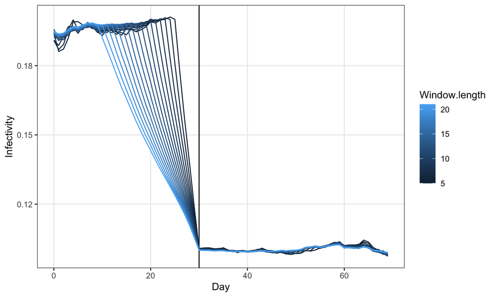

Sudden change to 50% infectivity at day 30.

## Second example

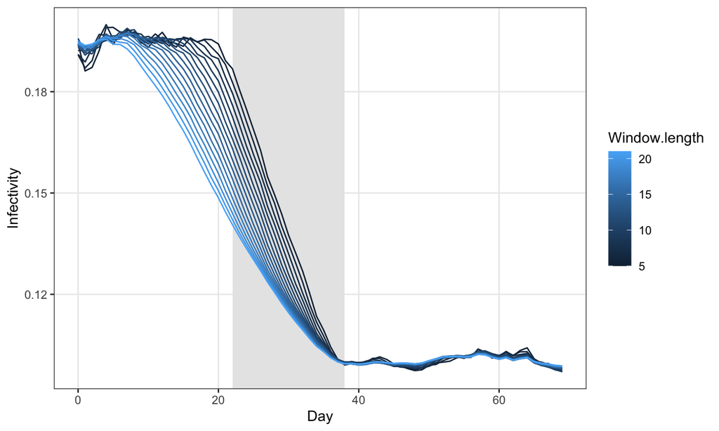

Linear decrease in infectivity from day 22 to 38.

## Searching for automatic approaches

## Linear decrease

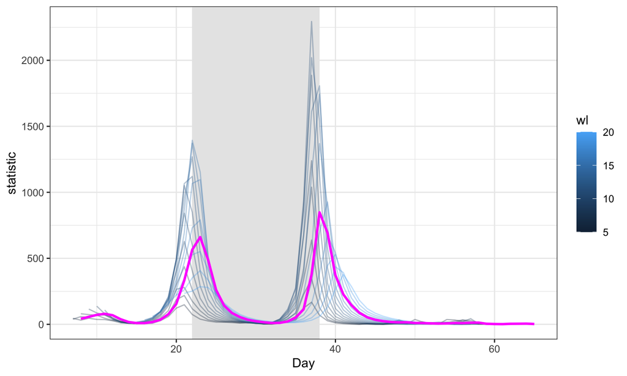

Moving windows -> sd -> Chow test multiple window lengths (blue) -> Mean (magenta)

## Sudden change

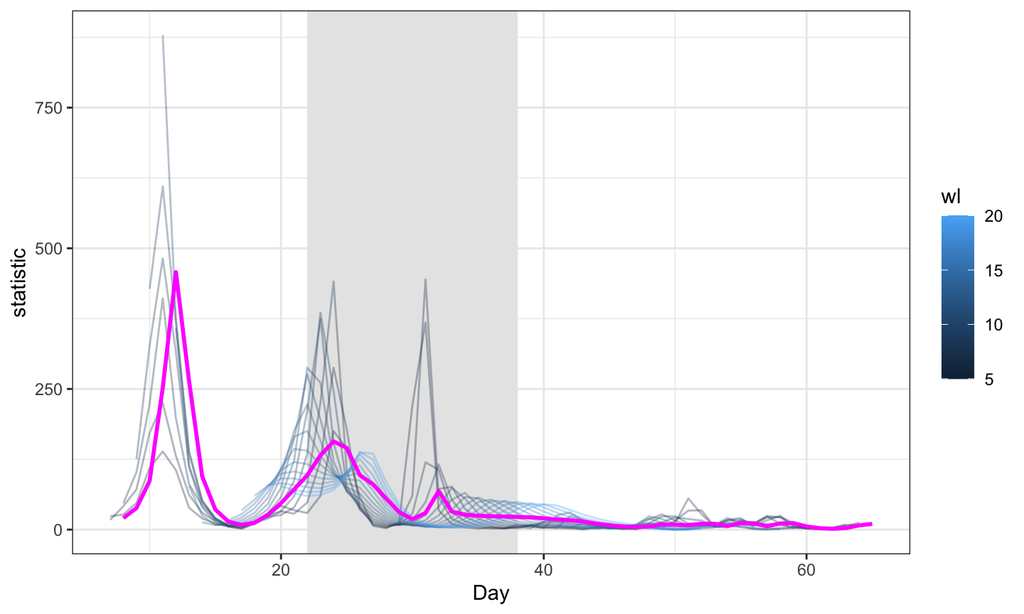

It doesn’t work. Let’s take a look at the s.d.

## Standard deviation

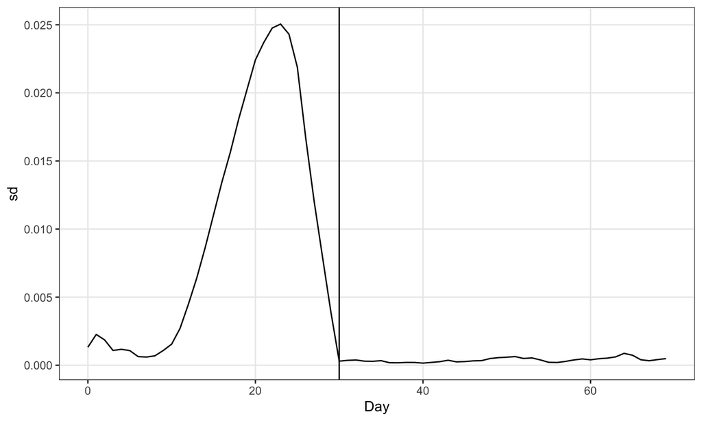

Standard deviation of the moving windows. We were lucky in the linear decrease case.

## Another approach

## Linear change

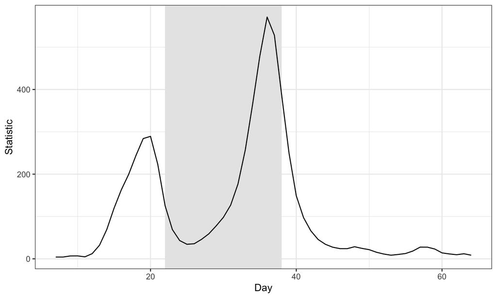

Moving windows -> Chow test at each point -> Mean of the statistic

## Sudden change

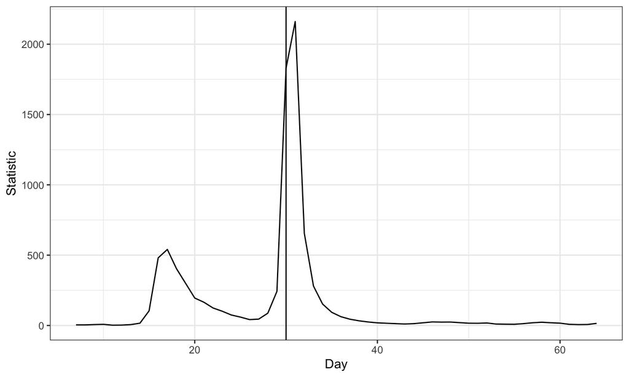

## Yet another approximation

## Two possible conventions

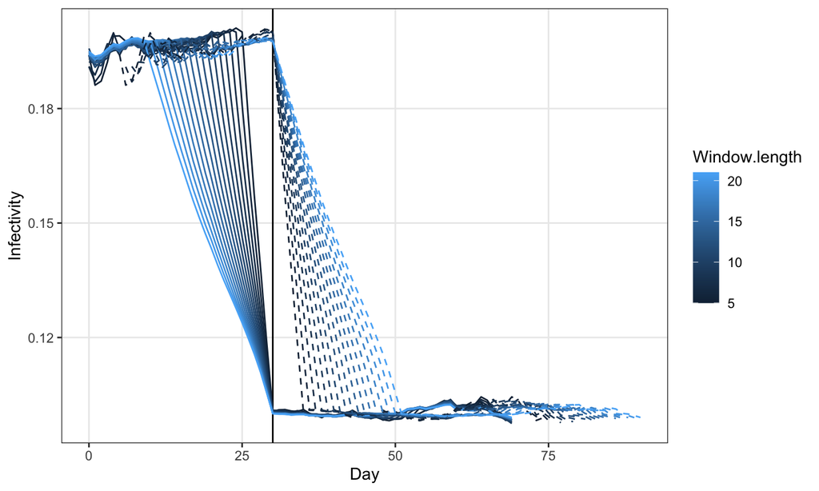

Actually, we need some kind of deconvolution.

## My shot at deconvolution

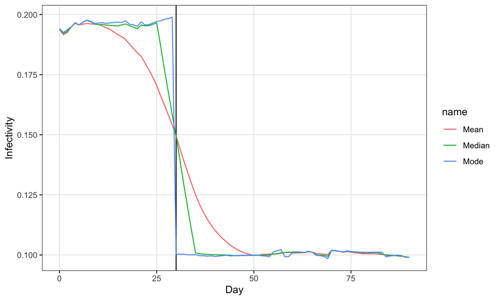

Great! Let’s see the Chow test of this series.

## Chow test

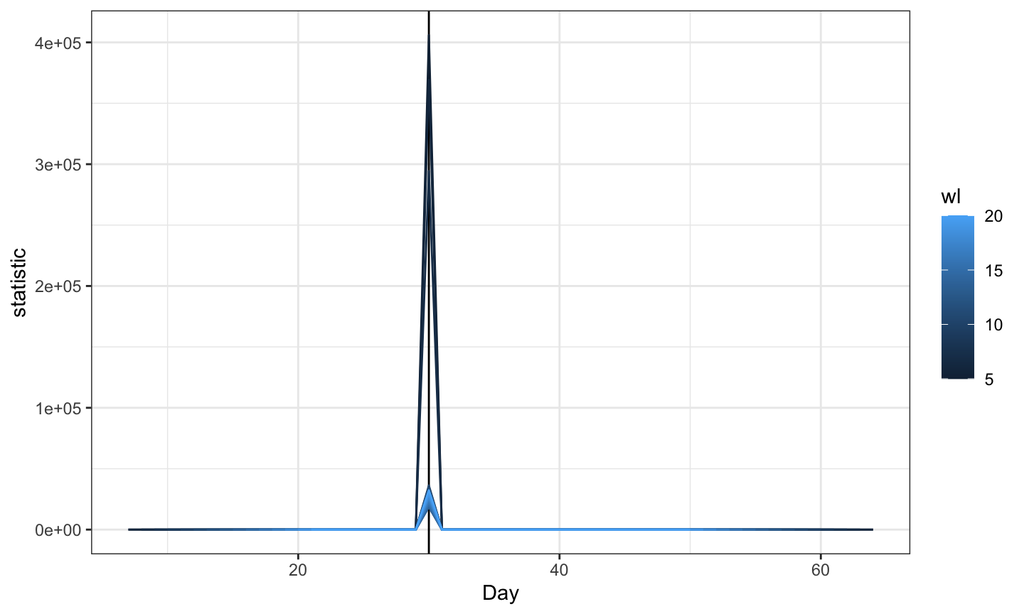

Perfect result. Let’s see with the gradual reduction.

## Second example

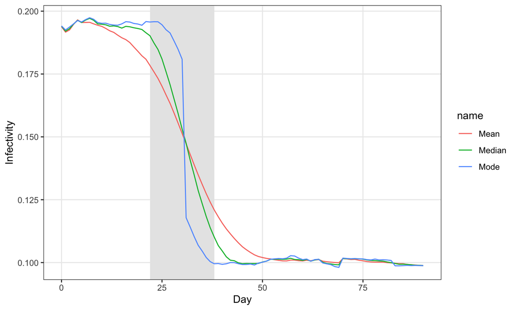

This mode might well do. Let’s do the Chow test.

## Chow test

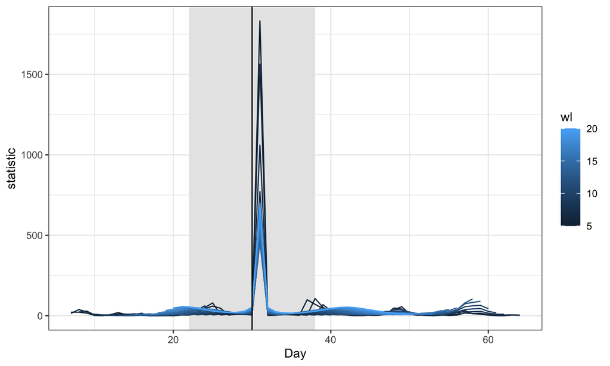

The Chow test signals more clearly the change in intercept than the two local peaks.

## Conclusion

- “Naked” moving windows do not identify linear decreases.
- Convoluted methods may lead to deceptive peaks.
- Moving Chow tests of the estimates also produce false peaks.
- Pedestrian “deconvolution” shows promise but still it can not identify linear decreases.
- Is there a way to do a real deconvolution?